# R Notebook

## Data Set-up

```r
library(here)
i_am("MixtureModels.Rmd")
```

```
here() starts at C:/Users/Blake/Dropbox/My PC (LAPTOP-R53ILDBG)/Documents/GitHub/Terzan-5
```

```r
# laptop data from csv
Terzan5 <- readr::read_csv(here("Data", "Terzan 5 X-ray events.csv"), col_types = list(.default = readr::col_guess()), )
# head(Terzan5)

#fishbowl data from ODS
# library(readODS)
# Terzan5 <- read_ods(here("Raw Data.ods"), col_types = list(.default = readr::col_guess()), )
#removing extraneous columns

T5 <- data.frame(Terzan5$x, Terzan5$y)
colnames(T5) <- c('x','y')

library(ggplot2)
library(ggpointdensity)
library(viridis)
#point density plot of all emissions
#ggplot(T5,aes(x,y)) +
  # geom_pointdensity(adjust = 0.05, size = 0.1, shape = "1") +
  # scale_color_viridis(direction = -1, option = "B", trans = "log", breaks = c(10, 100, 1000, 10000)) +
  # coord_fixed()
```

Filtering down to an area of interest with 5 celestial sources

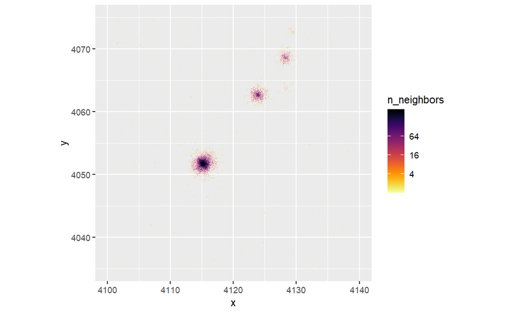

```r
library(tidyr)
library(plotly)
interestArea <- T5 %>%
  filter(x>4100 & x<4140 & y>4035 & y<4075)

#View area with 5 celestial sources
ggplot(interestArea,aes(x,y)) +
  geom_pointdensity(adjust = 0.05, size = 0.1, shape = "1") +
  scale_color_viridis(direction = -1, option = "B", trans = "log", breaks = c(4, 16, 64)) +
  coord_fixed()
```

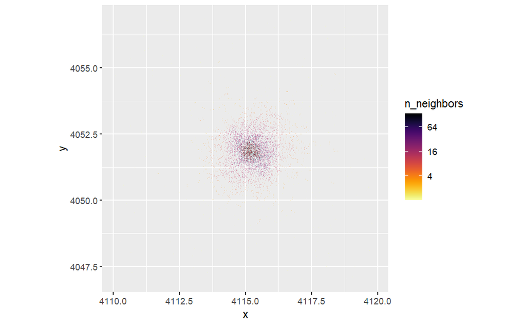

```r
interestAreaCS1 <- interestArea %>%
  filter(x>4110 & x<4120 & y>4047 & y<4057)

interestAreaCS2 <- interestArea %>%
  filter(x>4120 & x<4126 & y>4060 & y<4066)

ggplot(interestAreaCS1,aes(x,y)) +
  geom_pointdensity(adjust = 0.05, size = 0.1, shape = "1") +
  scale_color_viridis(direction = -1, option = "B", trans = "log", breaks = c(4, 16, 64)) +
  coord_fixed()
```

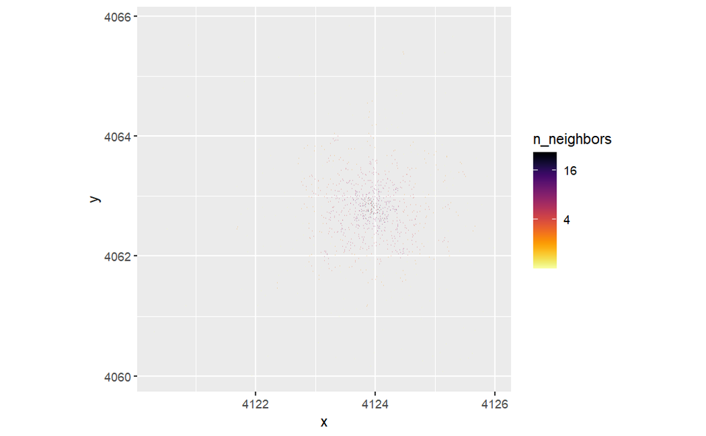

```r
ggplot(interestAreaCS2,aes(x,y)) +
  geom_pointdensity(adjust = 0.05, size = 0.1, shape = "1") +
  scale_color_viridis(direction = -1, option = "B", trans = "log", breaks = c(4, 16, 64)) +
  coord_fixed()
```

```r
a <- nrow(interestAreaCS1)
b <- nrow(interestAreaCS2)
c <- nrow(interestArea)

a
```

```
[1] 4352
```

```r
b
```

```
[1] 948
```

```r
c
```

```
[1] 8409
```

```r
a/c
```

```
[1] 0.5175407
```

```r
b/c
```

```
[1] 0.1127364
```

```r
a/(a+b)
```

```
[1] 0.8211321
```

```r
b/(a+b)
```

```
[1] 0.1788679
```

A second area with 2 faint celestial sources

```r
interestArea2 <- T5 %>%
  filter(x>4105 & x<4135 & y>4160 & y<4190)

#View area
ggplot(interestArea2,aes(x,y)) +
  geom_pointdensity(adjust = 0.05, size = 0.1, shape = "1") +
  scale_color_viridis(direction = -1, option = "B", trans = "log", breaks = c(4, 16, 64)) +
  coord_fixed()
```

[output not shown]

Separating the area with 2 sources into individual celestial sources.

```r
interestArea2S1 <- interestArea2 %>%
  filter(x>4110 & x<4120 & y>4177 & y<4187)

interestArea2S2 <- interestArea2 %>%
  filter(x>4124 & x<4134 & y>4173 & y<4183)

#Checking the number of data points in each area. ~ Approximately equal, expect lambda parameter in mixture model to be close to 0.5.
nrow(interestArea2S1)
```

```
[1] 383
```

```r
nrow(interestArea2S2)
```

```
[1] 389
```

Creating a random Dataset to use

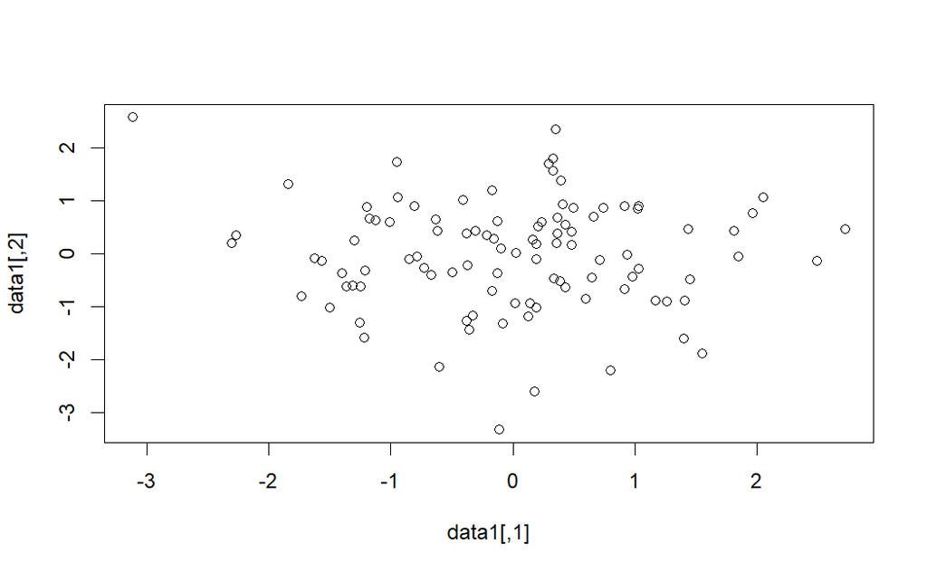

```r
set.seed(111)
data1 <- cbind(rnorm(100, mean = 0, sd = 1), rnorm(100, mean = 0, sd = 1))
data2 <- cbind(rnorm(100, mean = 5, sd = 1), rnorm(100, mean = 5, sd = 1))

datafull <- rbind(data1, data2)
plot(data1)
```

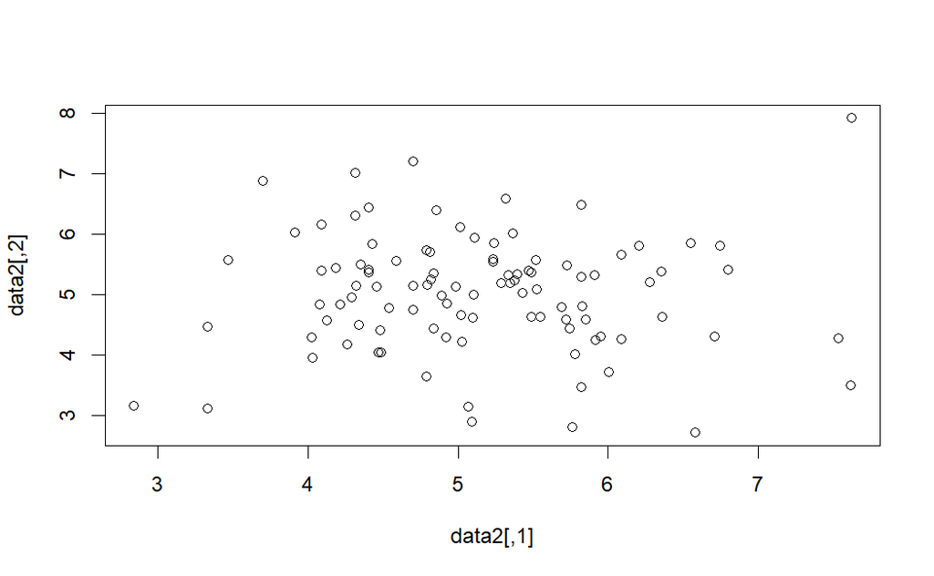

```r
plot(data2)
par(pty = "s")
```

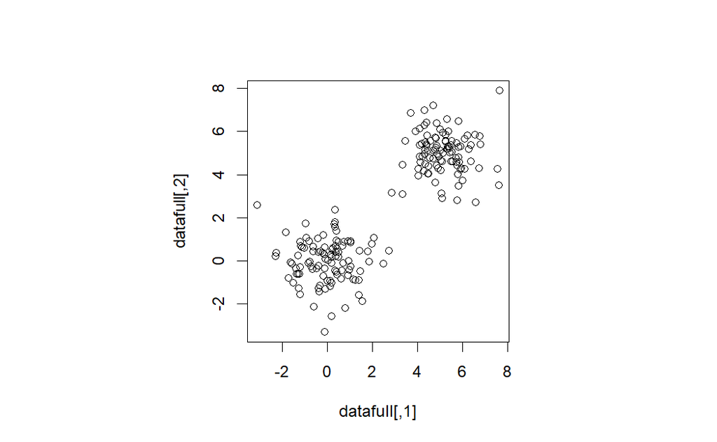

```r
plot(datafull)
```

## Functions Used

2D Moffat - used for finding optimal values of parameters from a single source.

```r
#2D Moffat Distribution
Moffat2DPDF <- function(parameters, x, y){
  x0 <- parameters[[1]]
  y0 <- parameters[[2]]
  alpha <- parameters[[3]]
  beta <- parameters[[4]]

  alpha <- pmax(alpha, 1e-6)
  beta <- pmax(beta, 1 + 1e-6)

  return(((beta-1)/(pi*alpha^2))*(1+((x - x0)^2 + (y - y0)^2)/alpha^2)^(-beta))
}

#Negative Log Likelihood of 2D Moffat Distribution
NLL2D <- function(parameters, x, y){
  predictedDens <- Moffat2DPDF(parameters, x, y)
  return(-sum(log(predictedDens)))
}

#Partial Derivatives of the Negative Log Likelihood
deriv2DNLL <- function(parameters, x, y){
  x0 <- parameters[[1]]
  y0 <- parameters[[2]]
  alpha <- parameters[[3]]
  beta <- parameters[[4]]

 dx0 <- -sum((2*beta*(x-x0))/(alpha^2 + (x-x0)^2 + (y-y0)^2))
 dy0 <- -sum((2*beta*(y-y0))/(alpha^2 + (x-x0)^2 + (y-y0)^2))
 dAlpha <- 2*sum(1/alpha + (beta*((x-x0)^2 + (y-y0)^2))/(alpha^3 + alpha*((x-x0)^2 + (y-y0)^2)))
 dBeta <- -sum(1/beta - log(1+((x-x0)^2 + (y-y0)^2)/alpha^2))

  return(c(dx0, dy0, dAlpha, dBeta))
}
```

Mixture Model
$$f(y_j) =
\lambda_1\frac{\beta_1-1}{\pi\alpha_1^2}\left[1 +
\frac{(x_j-\bar{x}_{1})^2 + (y_j -
\bar{y}_{1})^2}{\alpha_1^2}\right]^{-\beta_1} +
\lambda_2\frac{\beta_2-1}{\pi\alpha_2^2}\left[1 +
\frac{(x_j-\bar{x}_{2})^2 + (y_j -
\bar{y}_{2})^2}{\alpha_2^2}\right]^{-\beta_2}$$

```r
#A Mixture Model for 2 Moffat Distributions
MM2MOFFAT <- function(params, x, y){

  #component density 1
  lambda1 <- params[[1]]
  x1 <- params[[2]]
  y1 <- params[[3]]
  alpha1 <- params[[4]]
  beta1 <- params[[5]]

  #component density 2
  x2 <- params[[6]]
  y2 <- params[[7]]
  alpha2 <- params[[8]]
  beta2 <- params[[9]]

  #restrictions
  alpha1 <- pmax(alpha1, 1e-6)
  beta1 <- pmax(beta1, 1 + 1e-6)
  alpha2 <- pmax(alpha2, 1e-6)
  beta2 <- pmax(beta2, 1 + 1e-6)

  lambda1 <- pmin(lambda1, 1)
  lambda1 <- pmax(lambda1, 0)

  lambda2 <- 1 - lambda1

  #common terms
  c1 <- (beta1 - 1)/(pi*alpha1^2)
  c2 <- (beta2 - 1)/(pi*alpha2^2)
  v1 <- 1+(((x-x1)^2+(y-y1)^2)/alpha1^2)
  v2 <- 1+(((x-x2)^2+(y-y2)^2)/alpha2^2)

  Density <- lambda1*c1*v1^(-beta1) + (1 - lambda1)*c2*v2^(-beta2)

  return(Density)
}

#The Negative Log Likelihood of the Mixture Model
NLLMM2MOFFAT <- function(params, x, y){
  predictedDens <- MM2MOFFAT(params, x, y)
  return(-sum(log(predictedDens)))
}

#The partial derivatives of the Negative Log Likelihood
derivNLLMM2MOFFAT <- function(params, x, y){

  #component density 1
  lambda1 <- params[[1]]
  x1 <- params[[2]]
  y1 <- params[[3]]
  alpha1 <- params[[4]]
  beta1 <- params[[5]]

  #component density 2
  x2 <- params[[6]]
  y2 <- params[[7]]
  alpha2 <- params[[8]]
  beta2 <- params[[9]]

  lambda2 <- 1 - lambda1

  #common terms
  c1 <- (beta1 - 1)/(pi*alpha1^2)
  c2 <- (beta2 - 1)/(pi*alpha2^2)
  v1 <- 1+(((x-x1)^2+(y-y1)^2)/alpha1^2)
  v2 <- 1+(((x-x2)^2+(y-y2)^2)/alpha2^2)

  s1 <- lambda1/(pi*alpha1^2)
  s2 <- lambda2/(pi*alpha2^2)

  u <- lambda1*c1*v1^(-beta1) + (1 - lambda1)*c2*v2^(-beta2)

  #partial derivatives
  dLambda1 <- -sum(c1/(u*v1^beta1))

  dx1 <- -sum((2*lambda1*c1*beta1*(x-x1))/(u*(alpha1^2)*(v1^(beta1+1))))
  dx2 <- -sum((2*lambda2*c2*beta2*(x-x2))/(u*(alpha2^2)*(v2^(beta2+1))))
  dy1 <- -sum((2*lambda1*c1*beta1*(y-y1))/(u*(alpha1^2)*(v1^(beta1+1))))
  dy2 <- -sum((2*lambda2*c2*beta2*(y-y2))/(u*(alpha2^2)*(v2^(beta2+1))))

  dAlpha1 <- -sum(((2*lambda1*(beta1 - 1)/(pi*alpha1^3*v1^beta1))*((beta1*((x-x1)^2 + (y-y1)^2)/(v1*alpha1^2))-1))/u)
  dAlpha2 <- -sum(((2*lambda2*(beta2 - 1)/(pi*alpha2^3*v2^beta2))*((beta2*((x-x2)^2 + (y-y2)^2)/(v2*alpha2^2))-1))/u)

  dBeta1 <- -sum((s1*(1+log(v1)-beta1*log(v1)))/(u*v1^beta1))
  dBeta2 <- -sum((s2*(1+log(v2)-beta2*log(v2)))/(u*v2^beta2))

  return(c(dLambda1, dx1, dy1, dAlpha1, dBeta1, dx2, dy2, dAlpha2, dBeta2))
}
```

Used for visualisations

```r
MM2MOFFATimage <- function(grid, params){
  x <- grid[[1]]
  y <- grid[[2]]

  #component density 1
  lambda1 <- params[[1]]
  x1 <- params[[2]]
  y1 <- params[[3]]
  alpha1 <- params[[4]]
  beta1 <- params[[5]]

  #component density 2
  lambda2 <- params[[6]]
  x2 <- params[[7]]
  y2 <- params[[8]]
  alpha2 <- params[[9]]
  beta2 <- params[[10]]

  #restrictions
  alpha1 <- pmax(alpha1, 1e-6)
  beta1 <- pmax(beta1, 1 + 1e-6)
  alpha2 <- pmax(alpha2, 1e-6)
  beta2 <- pmax(beta2, 1 + 1e-6)

  lambda1 <- pmin(lambda1, 1)
  lambda1 <- pmax(lambda1, 1 - lambda2)
  lambda2 <- pmin(lambda2, 0 + lambda1)
  lambda2 <- pmax(lambda2, 1 - lambda1)

  c1 <- (beta1 - 1)/(pi*alpha1^2)
  c2 <- (beta2 - 1)/(pi*alpha2^2)
  v1 <- 1+(((x-x1)^2+(y-y1)^2)/alpha1^2)
  v2 <- 1+(((x-x2)^2+(y-y2)^2)/alpha2^2)

  return(lambda1*c1*v1^(-beta1) +
  lambda2*c2*v2^(-beta2))
}
```

Using the function NumericDeriv to ascertain that the partial derivatives are correct. *When using a sequence of values for x and y, the numericderiv function returns a different value for than the function itself.

```r
myenv <- new.env()
assign("lambda1", 0.5, envir = myenv)
assign("beta1", 2, envir = myenv)
assign("alpha1", 1, envir = myenv)
assign("x1", 40, envir = myenv)
assign("y1", 20, envir = myenv)
assign("lambda2", 0.5, envir = myenv)
assign("beta2", 1.8, envir = myenv)
assign("alpha2", 1.2, envir = myenv)
assign("x2", 30, envir = myenv)
assign("y2", 30, envir = myenv)
assign("x", seq(30, 40, length = 11), envir = myenv)
assign("y", seq(20, 30, length = 11), envir = myenv)

f <- function(lambda1, beta1, alpha1, x1, y1, lambda2, beta2, alpha2, x2, y2, x, y){
  #common terms
  c1 <- (beta1 - 1)/(pi*alpha1^2)
  c2 <- (beta2 - 1)/(pi*alpha2^2)
  v1 <- 1+(((x-x1)^2+(y-y1)^2)/alpha1^2)
  v2 <- 1+(((x-x2)^2+(y-y2)^2)/alpha2^2)

  predDensity <- lambda1*c1*v1^(-beta1) + lambda2*c2*v2^(-beta2)
  return(-sum(log(predDensity)))
}

f(lambda1 = 0.5, beta1=2, alpha1=1, x1=40, y1=20, lambda2=0.5, beta2=1.8, alpha2=1.2, x2=30, y2=30, x= seq(30, 40, length = 11), y= seq(20, 30, length = 11))
```

```
[1] 99.66164
```

```r
outputnumderiv <- numericDeriv(quote(f(lambda1, beta1, alpha1, x1, y1, lambda2, beta2, alpha2, x2, y2, x, y)), c("lambda1", "x1", "y1", "alpha1", "beta1", "lambda2", "x2", "y2", "alpha2", "beta2"), myenv)


outputnumderiv
```

```
[1] 99.66164
attr(,"gradient")
          [,1]      [,2]       [,3]      [,4]     [,5]     [,6]      [,7]     [,8]
[1,] -6.346201 0.9546835 -0.9546836 -6.155265 10.23127 -15.6538 -2.080719 2.080719
          [,9]    [,10]
[1,] -9.936493 20.57264
```

```r
derivf <- function(lambda1, beta1, alpha1, x1, y1, lambda2, beta2, alpha2, x2, y2, x, y){
  #common terms
  c1 <- (beta1 - 1)/(pi*alpha1^2)
  c2 <- (beta2 - 1)/(pi*alpha2^2)
  v1 <- 1+(((x-x1)^2+(y-y1)^2)/alpha1^2)
  v2 <- 1+(((x-x2)^2+(y-y2)^2)/alpha2^2)

  s1 <- lambda1/(pi*alpha1^2)
  s2 <- lambda2/(pi*alpha2^2)

  u <- lambda1*c1*v1^(-beta1) + lambda2*c2*v2^(-beta2)

  #partial derivatives
  dLambda1 <- -sum(c1/(u*v1^beta1))
  dLambda2 <- -sum(c2/(u*v2^beta2))

  dx1 <- -sum((2*lambda1*c1*beta1*(x-x1))/(u*(alpha1^2)*(v1^(beta1+1))))
  dx2 <- -sum((2*lambda2*c2*beta2*(x-x2))/(u*(alpha2^2)*(v2^(beta2+1))))
  dy1 <- -sum((2*lambda1*c1*beta1*(y-y1))/(u*(alpha1^2)*(v1^(beta1+1))))
  dy2 <- -sum((2*lambda2*c2*beta2*(y-y2))/(u*(alpha2^2)*(v2^(beta2+1))))

  dAlpha1 <- -sum(((2*lambda1*(beta1 - 1)/(pi*alpha1^3*v1^beta1))*((beta1*((x-x1)^2 + (y-y1)^2)/(v1*alpha1^2))-1))/u)
  dAlpha2 <- -sum(((2*lambda2*(beta2 - 1)/(pi*alpha2^3*v2^beta2))*((beta2*((x-x2)^2 + (y-y2)^2)/(v2*alpha2^2))-1))/u)

  dBeta1 <- -sum((s1*(1+log(v1)-beta1*log(v1)))/(u*v1^beta1))
  dBeta2 <- -sum((s2*(1+log(v2)-beta2*log(v2)))/(u*v2^beta2))

  return(c(dLambda1, dx1, dy1, dAlpha1, dBeta1, dLambda2, dx2, dy2, dAlpha2, dBeta2))
}


outputderivf <- derivf(lambda1 = 0.5, beta1=2, alpha1=1, x1=40, y1=20, lambda2=0.5, beta2=1.8, alpha2=1.2, x2=30, y2=30, x= seq(30, 40, length = 11), y= seq(20, 30, length = 11))

outputderivf
```

```
 [1]  -6.3462018   0.9546836  -0.9546836  -6.1552650  10.2312709 -15.6537982  -2.0807186
 [8]   2.0807186  -9.9364930  20.5726358
```

Checking that the Mixture Model of 2 Moffat distributions when integrated is equal to 1. The results are close enough to one in this instance.

```r
library(pracma)
#test
testParams <- c(lambda1 = 0.5, x1 = 1, y1 = 4, alpha1 = 0.4, beta1 = 2, x2 = 3, y2 = -2, alpha2 = 1.2, beta2 = 1.3)
MixtureIntegral <- integral2(MM2MOFFAT, xmin = -40, xmax = 40, ymin = -40, ymax = 40, params = testParams)[[1]]
MixtureIntegral
```

```
[1] 0.9385551
```

```r
#test2
testParams2 <- c(lambda1 = 0.7, x1 = 40, y1 = 33, alpha1 = 1.2, beta1 = 1.7, x2 = 3, y2 = -2, alpha2 = 1.2, beta2 = 1.3)
MixtureIntegral2 <- integral2(MM2MOFFAT, xmin = -100, xmax = 100, ymin = -100, ymax = 100, params = testParams2)[[1]]
MixtureIntegral2
```

```
[1] 0.9063673
```

```r
#test3
testParams3 <- c(lambda1 = 0.55, x1 = 0, y1 = 0, alpha1 = 1.2, beta1 = 2, x2 = 2, y2 = 2, alpha2 = 1.2, beta2 = 2)
MixtureIntegral3 <- integral2(MM2MOFFAT, xmin = -50, xmax = 50, ymin = -50, ymax = 50, params = testParams3)[[1]]
MixtureIntegral3
```

```
[1] 1.017327
```

```r
#A Mixture Model for 2 Moffat Distributions
MM2MOFFATnorestrictions <- function(params, x, y){

  #component density 1
  lambda1 <- params[[1]]
  x1 <- params[[2]]
  y1 <- params[[3]]
  alpha1 <- params[[4]]
  beta1 <- params[[5]]

  #component density 2
  lambda2 <- params[[6]]
  x2 <- params[[7]]
  y2 <- params[[8]]
  alpha2 <- params[[9]]
  beta2 <- params[[10]]

  #common terms
  c1 <- (beta1 - 1)/(pi*alpha1^2)
  c2 <- (beta2 - 1)/(pi*alpha2^2)
  v1 <- 1+(((x-x1)^2+(y-y1)^2)/alpha1^2)
  v2 <- 1+(((x-x2)^2+(y-y2)^2)/alpha2^2)

  Density <- lambda1*c1*v1^(-beta1) + lambda2*c2*v2^(-beta2)
  #return the Negative Log-Likelihood
  return(-sum(log(Density)))
}

#The partial derivatives of the Negative Log Likelihood
derivNLLMM2MOFFATnorestrictions <- function(params, x, y){

  #component density 1
  lambda1 <- params[[1]]
  x1 <- params[[2]]
  y1 <- params[[3]]
  alpha1 <- params[[4]]
  beta1 <- params[[5]]

  #component density 2
  lambda2 <- params[[6]]
  x2 <- params[[7]]
  y2 <- params[[8]]
  alpha2 <- params[[9]]
  beta2 <- params[[10]]


  #common terms
  c1 <- (beta1 - 1)/(pi*alpha1^2)
  c2 <- (beta2 - 1)/(pi*alpha2^2)
  v1 <- 1+(((x-x1)^2+(y-y1)^2)/alpha1^2)
  v2 <- 1+(((x-x2)^2+(y-y2)^2)/alpha2^2)

  s1 <- lambda1/(pi*alpha1^2)
  s2 <- lambda2/(pi*alpha2^2)

  u <- lambda1*c1*v1^(-beta1) + lambda2*c2*v2^(-beta2)

  #partial derivatives
  dLambda1 <- -sum(c1/(u*v1^beta1))
  dLambda2 <- -sum(c2/(u*v2^beta2))

  dx1 <- -sum((2*lambda1*c1*beta1*(x-x1))/(u*(alpha1^2)*(v1^(beta1+1))))
  dx2 <- -sum((2*lambda2*c2*beta2*(x-x2))/(u*(alpha2^2)*(v2^(beta2+1))))
  dy1 <- -sum((2*lambda1*c1*beta1*(y-y1))/(u*(alpha1^2)*(v1^(beta1+1))))
  dy2 <- -sum((2*lambda2*c2*beta2*(y-y2))/(u*(alpha2^2)*(v2^(beta2+1))))

  dAlpha1 <- -sum(((2*lambda1*(beta1 - 1)/(pi*alpha1^3*v1^beta1))*((beta1*((x-x1)^2 + (y-y1)^2)/(v1*alpha1^2))-1))/u)
  dAlpha2 <- -sum(((2*lambda1*(beta1 - 1)/(pi*alpha1^3*v1^beta1))*((beta1*((x-x1)^2 + (y-y1)^2)/(v1*alpha1^2))-1))/u)

  dBeta1 <- -sum((s1*(1+log(v1)-beta1*log(v1)))/(u*v1^beta1))
  dBeta2 <- -sum((s2*(1+log(v2)-beta2*log(v2)))/(u*v2^beta2))

  return(c(dLambda1, dx1, dy1, dAlpha1, dBeta1, dLambda2, dx2, dy2, dAlpha2, dBeta2))
}
```

## Optimising Parameters

The randomly created dataset - 2 clusters with an equal number of points. I expect the values of lambda (the mixing proportion) to be close to 0.5.

First find the optimised parameters of each cluster individually

```r
#Cluster 1
initParams = c(x0 = 0, y0 = 0, alpha = 1, beta = 1)
lowerBounds = c(0, 0, 1e-6, 1+1e-6)
result <- optim(par = initParams, fn = NLL2D, gr = deriv2DNLL, x = data1[,1], y = data1[,2], method = "L-BFGS-B", lower = lowerBounds)
opt <- result$par

#Cluster 2
initParams2 = c(x0 = 5, y0 = 5, alpha = 1, beta = 1)
lowerBounds = c(0, 0, 1e-6, 1+1e-6)
result2 <- optim(par = initParams2, fn = NLL2D, gr = deriv2DNLL, x = data2[,1], y = data2[,2], method = "L-BFGS-B", lower = lowerBounds)
opt2 <- result2$par

opt
```

```
        x0         y0      alpha       beta
0.08680183 0.45820109 0.82923147 1.86796143
```

```r
opt2
```

```
       x0        y0     alpha      beta
5.0404452 5.0068497 0.8623493 1.9095936
```

Next set up requirements of the Mixture Model

```r
#Set the initial parameters for the Mixture Model, use the optimised parameters from the individual clusters
initialParams <- c(lambda1 = 0.5, x1 = opt[[1]], y1 = opt[[2]], alpha1 = opt[[3]], beta1 = opt[[4]], x2 = opt2[[1]], y2 = opt2[[2]], alpha2 = opt2[[3]], beta2 = opt2[[4]])

#The set the bounds for the Mixture Model, some of these are just arbitrary high numbers.
lowerbounds = c(1e-6, -100, -100, 1e-6, 1+1e-6, -100, -100, 1e-6, 1+1e-6)
upperbounds = c(1, 100, 100, 100, 100, 100, 100, 100, 100)
```

Try to optimise the mixture model - This set up (method = “L-BFGS-B”, no upper bound) yields a convergence error, yet the output optimised parameters are different from the input initial paramters. *I ran this code chunk after I cleared my environment and reloaded everything within this Markdown and it worked without a convergence error.

```r
#Optimise Mixture Model
MMresult <- optim(par = initialParams, fn = NLLMM2MOFFAT, gr = derivNLLMM2MOFFAT, x = datafull[,1], y = datafull[,2], method = "L-BFGS-B", lower = lowerbounds)

#Check for convergence
MMresult
```

```
$par
   lambda1         x1         y1     alpha1      beta1         x2         y2     alpha2
0.57763493 0.08215709 0.42717595 0.85584848 1.88006927 5.04596473 5.01471810 0.87208797
     beta2
2.01156395

$value
[1] 729.0463

$counts
function gradient
     407      407

$convergence
[1] 0

$message
[1] "CONVERGENCE: REL_REDUCTION_OF_F <= FACTR*EPSMCH"
```

```r
#Compare optimised parameters of the individual clusters to the mixture model
opt
```

```
        x0         y0      alpha       beta
0.08680183 0.45820109 0.82923147 1.86796143
```

```r
opt2
```

```
       x0        y0     alpha      beta
5.0404452 5.0068497 0.8623493 1.9095936
```

```r
out <- MMresult$par
out
```

```
   lambda1         x1         y1     alpha1      beta1         x2         y2     alpha2
0.57763493 0.08215709 0.42717595 0.85584848 1.88006927 5.04596473 5.01471810 0.87208797
     beta2
2.01156395
```

```r
#Optimise Mixture Model
MMresult <- optim(par = initialParams, fn = NLLMM2MOFFAT, gr = derivNLLMM2MOFFAT, x = datafull[,1], y = datafull[,2], method = "L-BFGS-B", lower = lowerbounds, upper = upperbounds)

#Check for convergence
MMresult
```

```
$par
    lambda1          x1          y1      alpha1       beta1          x2          y2
 0.56728494  0.01014197 -0.11732431  1.29880469  1.88368630  5.13137109  5.15125702
     alpha2       beta2
 0.92008662  2.10002419

$value
[1] 720.9041

$counts
function gradient
     463      463

$convergence
[1] 0

$message
[1] "CONVERGENCE: REL_REDUCTION_OF_F <= FACTR*EPSMCH"
```

```r
#Compare optimised parameters of the individual clusters to the mixture model
opt
```

```
        x0         y0      alpha       beta
0.08680183 0.45820109 0.82923147 1.86796143
```

```r
opt2
```

```
       x0        y0     alpha      beta
5.0404452 5.0068497 0.8623493 1.9095936
```

```r
out <- MMresult$par
out
```

```
    lambda1          x1          y1      alpha1       beta1          x2          y2
 0.56728494  0.01014197 -0.11732431  1.29880469  1.88368630  5.13137109  5.15125702
     alpha2       beta2
 0.92008662  2.10002419
```

```r
#Optimise Mixture Model
MMresult <- optim(par = initialParams, fn = NLLMM2MOFFAT, gr = derivNLLMM2MOFFAT, x = datafull[,1], y = datafull[,2], method = "CG")

#Check for convergence
MMresult
```

```
$par
    lambda1          x1          y1      alpha1       beta1          x2          y2
 2.53848896 -0.04497497  0.09046874  1.50478102  1.47662140  5.10387091  5.07278238
     alpha2       beta2
-0.07113352 -3.11074460

$value
[1] 1091.691

$counts
function gradient
     555      101

$convergence
[1] 1

$message
NULL
```

```r
#Compare optimised parameters of the individual clusters to the mixture model
opt
```

```
        x0         y0      alpha       beta
0.08680183 0.45820109 0.82923147 1.86796143
```

```r
opt2
```

```
       x0        y0     alpha      beta
5.0404452 5.0068497 0.8623493 1.9095936
```

```r
out <- MMresult$par
out
```

```
    lambda1          x1          y1      alpha1       beta1          x2          y2
 2.53848896 -0.04497497  0.09046874  1.50478102  1.47662140  5.10387091  5.07278238
     alpha2       beta2
-0.07113352 -3.11074460
```

Another Set Up (where the gradient function isn’t included) - This converges and gives different values for the parameters. The values of alpha and beta are approx 3 times greater than the input values

```r
#Optimise Mixture Model
MMresult <- optim(par = initialParams, fn = NLLMM2MOFFAT, x = datafull[,1], y = datafull[,2], method = "L-BFGS-B", lower = lowerbounds, upper = upperbounds)

#Check for convergence
MMresult
```

```
$par
     lambda1           x1           y1       alpha1        beta1           x2
 0.500237518 -0.007038051 -0.008912396  4.345912023 10.686934227  5.107872309
          y2       alpha2        beta2
 5.050041748  2.061969257  4.399971304

$value
[1] 695.8935

$counts
function gradient
      77       77

$convergence
[1] 0

$message
[1] "CONVERGENCE: REL_REDUCTION_OF_F <= FACTR*EPSMCH"
```

```r
#Compare optimised parameters of the individual clusters to the mixture model
opt
```

```
        x0         y0      alpha       beta
0.08680183 0.45820109 0.82923147 1.86796143
```

```r
opt2
```

```
       x0        y0     alpha      beta
5.0404452 5.0068497 0.8623493 1.9095936
```

```r
out <- MMresult$par
out
```

```
     lambda1           x1           y1       alpha1        beta1           x2
 0.500237518 -0.007038051 -0.008912396  4.345912023 10.686934227  5.107872309
          y2       alpha2        beta2
 5.050041748  2.061969257  4.399971304
```

#On the Data Interest Area 2 - 2 celestial sources This doesn’t yield a convergence error. However, the value of lambda1 is extremely high.

```r
initialParams <- c(lambda1 = 0.5, x1 = mean(interestArea2S2$x), y1 = mean(interestArea2S2$y), alpha1 = 0.5, beta1 = 1.9, x2 = mean(interestArea2S1$x), y2 = mean(interestArea2S1$y), alpha2 = 0.5, beta2 = 1.9)
lowerbounds = c(0, 3900, 3900, 1e-6, 1+1e-6, 3900, 3900, 1e-6, 1+1e-6)
upperbounds = c(1, 4400, 4400, Inf, Inf, 4400, 4400, Inf, Inf)

MMresult <- optim(par = initialParams, fn = NLLMM2MOFFAT, gr = derivNLLMM2MOFFAT, x = interestArea2$x, y = interestArea2$y, method = "L-BFGS-B", lower = lowerbounds, upper = upperbounds)

MMresult
```

```
$par
     lambda1           x1           y1       alpha1        beta1           x2
   0.9117258 4128.5517426 4178.4439589    1.2644510    1.3912999 4115.4866034
          y2       alpha2        beta2
4182.0921781    1.1908409    1.5954168

$value
[1] 10249.47

$counts
function gradient
      31       31

$convergence
[1] 0

$message
[1] "CONVERGENCE: REL_REDUCTION_OF_F <= FACTR*EPSMCH"
```

```r
out <- MMresult$par
```

Visualising the results

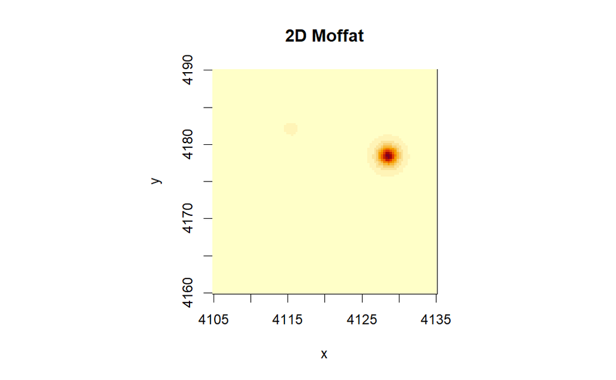

```r
xRange <- seq(4105, 4135, length = 100)
yRange <- seq(4160, 4190, length = 100)
grid <- expand.grid(x = xRange, y = yRange)

oparams <- c(out[[1]], out[[2]], out[[3]], out[[4]], out[[5]], 1-out[[1]], out[[6]], out[[7]], out[[8]], out[[9]])
zMM <- MM2MOFFATimage(grid, params = oparams)
zmat <- matrix(zMM, nrow = length(xRange), ncol = length(yRange))
par(pty = "s")
#This is an image of the mixture model with the optimised results
image(xRange, yRange, zmat, xlab = "x", ylab = "y", main = "2D Moffat")
```

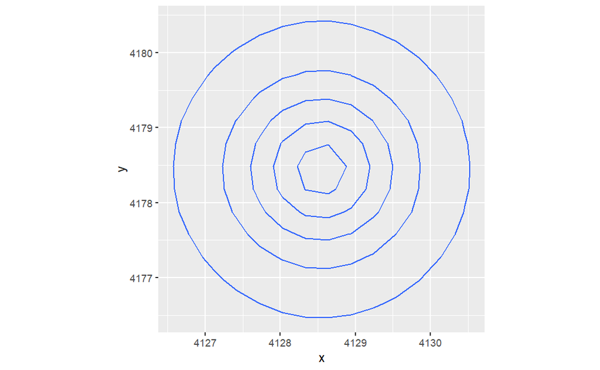

```r
contours <- ggplot(grid, aes(x = x, y = y)) +
  stat_contour(aes(z = zMM), bins = 6) +
  coord_fixed()

contours
```

```r
#this is the data
interestArea2Model <- ggplot(interestArea2, aes(x = x, y = y)) +
  geom_pointdensity(adjust = 0.05, size = 0.1, shape = "1") +
  scale_color_viridis(direction = -1, option = "B", trans = "log", breaks = c(4, 16, 64)) +
  coord_fixed()

interestArea2Model
```

[output not shown]

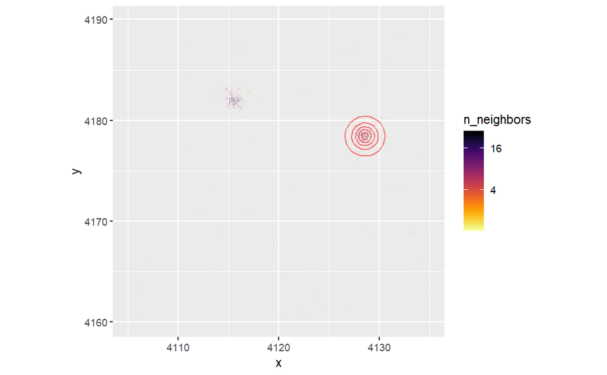

```r
# interestArea2Model2 <- ggplot(interestArea2, aes(x = x, y = y)) +
#   geom_point(size = 0.5, shape = "1") +
#   coord_fixed()
#
# interestArea2Model2

MMcontourData <- ggplot_build(contours)$data[[1]] #extracting the contours (from the optimised function)
MMcombined <- interestArea2Model + geom_path(data = MMcontourData, aes(x = x, y = y, group = group), color = "red", alpha = 0.5)

#this is the contours of the model overlayed on the data
MMcombined
```

This doesn’t include the gradient function in optim.

```r
initialParams <- c(lambda1 = 0.5, x1 = mean(interestArea2S2$x), y1 = mean(interestArea2S2$y), alpha1 = 0.5, beta1 = 1.9, x2 = mean(interestArea2S1$x), y2 = mean(interestArea2S1$y), alpha2 = 0.5, beta2 = 1.9)
lowerbounds = c(0, 3900, 3900, 1e-6, 1+1e-6, 3900, 3900, 1e-6, 1+1e-6)
upperbounds = c(1, 4400, 4400, Inf, Inf, 4400, 4400, Inf, Inf)

MMresult <- optim(par = initialParams, fn = NLLMM2MOFFAT, x = interestArea2$x, y = interestArea2$y, method = "L-BFGS-B", lower = lowerbounds, upper = upperbounds)

MMresult
```

```
$par
     lambda1           x1           y1       alpha1        beta1           x2
   0.5026288 4128.3942679 4178.5055429    0.8628277    1.3104019 4115.5824786
          y2       alpha2        beta2
4182.0596125    0.9089872    1.3215997

$value
[1] 9791.485

$counts
function gradient
      33       33

$convergence
[1] 0

$message
[1] "CONVERGENCE: REL_REDUCTION_OF_F <= FACTR*EPSMCH"
```

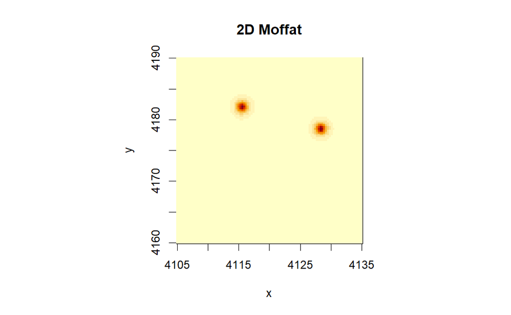

```r
out <- MMresult$par
xRange <- seq(4105, 4135, length = 100)
yRange <- seq(4160, 4190, length = 100)
grid <- expand.grid(x = xRange, y = yRange)

oparams <- c(out[[1]], out[[2]], out[[3]], out[[4]], out[[5]], 1-out[[1]], out[[6]], out[[7]], out[[8]], out[[9]])
zMM <- MM2MOFFATimage(grid, params = oparams)
zmat <- matrix(zMM, nrow = length(xRange), ncol = length(yRange))
par(pty = "s")
#This is an image of the mixture model with the optimised results
image(xRange, yRange, zmat, xlab = "x", ylab = "y", main = "2D Moffat")
```

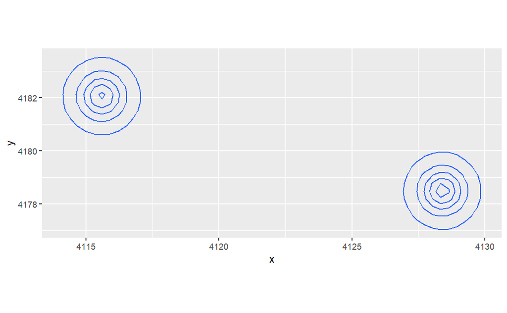

```r
contours <- ggplot(grid, aes(x = x, y = y)) +
  stat_contour(aes(z = zMM), bins = 6) +
  coord_fixed()

contours
```

```r
#this is the data
interestArea2Model <- ggplot(interestArea2, aes(x = x, y = y)) +
  geom_pointdensity(adjust = 0.05, size = 0.1, shape = "1") +
  scale_color_viridis(direction = -1, option = "B", trans = "log", breaks = c(4, 16, 64)) +
  coord_fixed()

interestArea2Model
```

[output not shown]

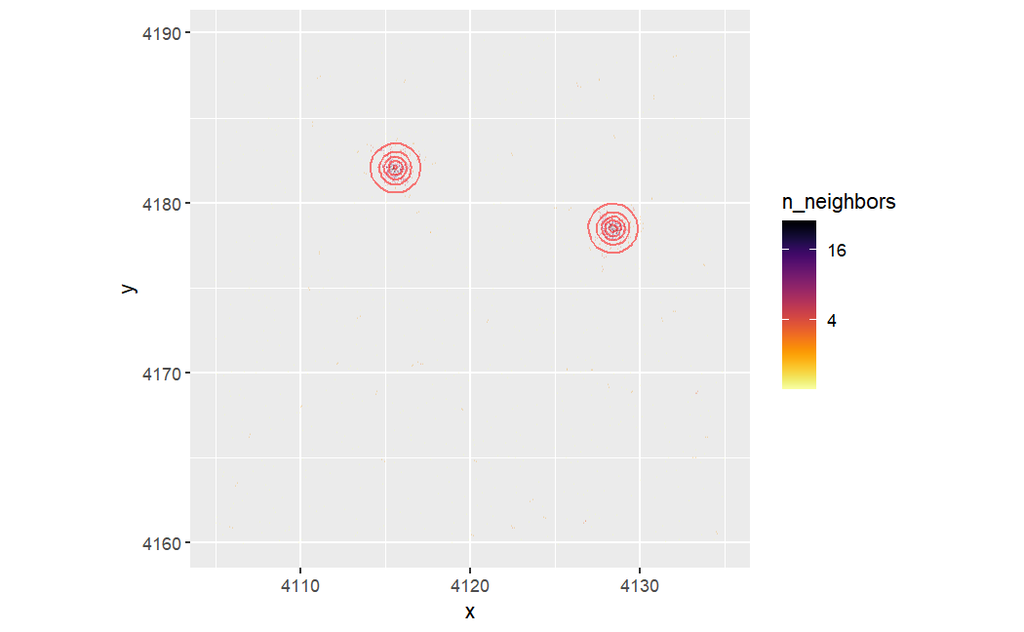

```r
# interestArea2Model2 <- ggplot(interestArea2, aes(x = x, y = y)) +
#   geom_point(size = 0.5, shape = "1") +
#   coord_fixed()
#
# interestArea2Model2

MMcontourData <- ggplot_build(contours)$data[[1]] #extracting the contours (from the optimised function)
MMcombined <- interestArea2Model + geom_path(data = MMcontourData, aes(x = x, y = y, group = group), color = "red", alpha = 0.5)

#this is the contours of the model overlayed on the data
MMcombined
```

```r
initialParams <- c(lambda1 = 0.5, x1 = mean(interestArea2S2$x), y1 = mean(interestArea2S2$y), alpha1 = 0.5, beta1 = 1.9, x2 = mean(interestArea2S1$x), y2 = mean(interestArea2S1$y), alpha2 = 0.5, beta2 = 1.9)
lowerbounds = c(0, 3900, 3900, 1e-6, 1+1e-6, 3900, 3900, 1e-6, 1+1e-6)
upperbounds = c(1, 4400, 4400, Inf, Inf, 4400, 4400, Inf, Inf)

MMresult <- optim(par = initialParams, fn = NLLMM2MOFFAT, gr = derivNLLMM2MOFFAT, x = interestArea2$x, y = interestArea2$y, method = "L-BFGS-B", lower = lowerbounds)

MMresult
```

```
$par
     lambda1           x1           y1       alpha1        beta1           x2
   0.9057763 4128.6060592 4178.4317988    0.9089172    1.6610887 4115.4608861
          y2       alpha2        beta2
4182.1045614    0.7834861    1.8772327

$value
[1] 10900.19

$counts
function gradient
      46       46

$convergence
[1] 52

$message
[1] "ERROR: ABNORMAL_TERMINATION_IN_LNSRCH"
```

```r
out <- MMresult$par
```

Interest Area - 5 Celestial Sources Convergence error occurs depending on the input of the inital value of lambda

```r
initialParams <- c(lambda1 = 0.2, x1 = 4115.261, y1 = 4051.904, alpha1 = 0.683, beta1 = 1.9, x2 = 4124, y2 = 4063, alpha2 = 0.5, beta2 = 1.9)
#the initial parameters for the first component density are the optimal parameters when testing the 2D Moffat Model on an individual source.

lowerbounds = c(0, 3000, 3000, 1e-6, 1+1e-6, 3000, 3000, 1e-6, 1+1e-6)
upperbounds = c(1, 5000, 5000, Inf, Inf, 5000, 5000, Inf, Inf)

MMresult <- optim(par = initialParams, fn = NLLMM2MOFFAT, gr = derivNLLMM2MOFFAT, x = interestArea$x, y = interestArea$y, method = "L-BFGS-B", lower = lowerbounds, control = list(trace = 6))
```

[output not shown]

[output cut: 92 more lines]

[output not shown]

```r
MMresult
```

```
$par
     lambda1           x1           y1       alpha1        beta1           x2
   0.9074952 4115.2562934 4051.8884346    0.8257522    1.5261540 4124.0056440
          y2       alpha2        beta2
4062.9800966    0.7716105    1.7404645

$value
[1] 50216.14

$counts
function gradient
      46       46

$convergence
[1] 52

$message
[1] "ERROR: ABNORMAL_TERMINATION_IN_LNSRCH"
```

```r
out <- MMresult$par
```

Visualising the Results - this one is worse than the one that I had managed to obtain previously.

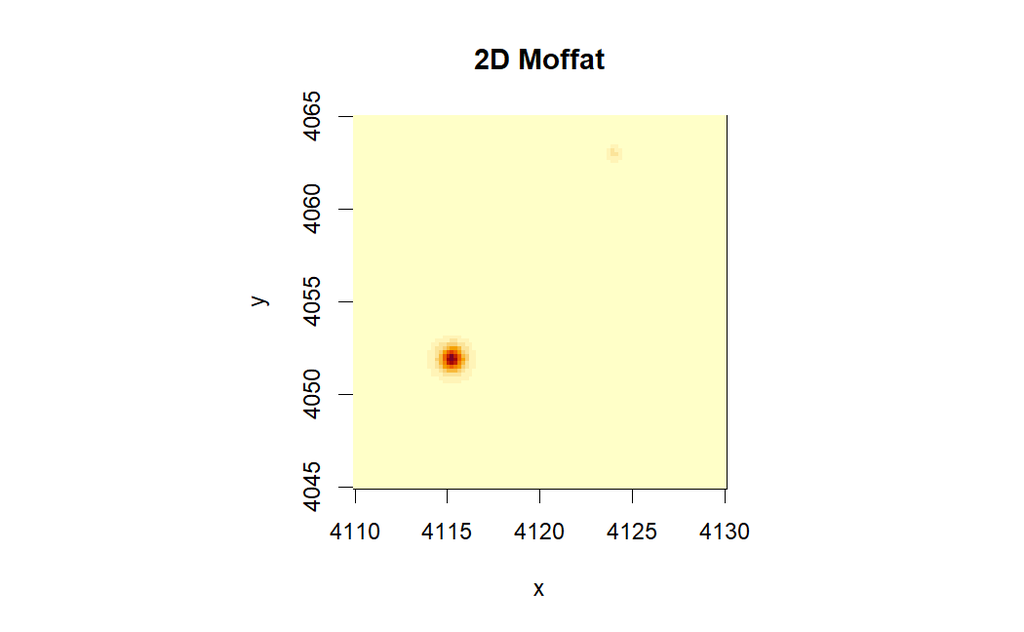

```r
xRange <- seq(4110, 4130, length = 100)
yRange <- seq(4045, 4065, length = 100)
grid <- expand.grid(x = xRange, y = yRange)

oparams <- c(out[[1]], out[[2]], out[[3]], out[[4]], out[[5]], 1-out[[1]], out[[6]], out[[7]], out[[8]], out[[9]])
zMM <- MM2MOFFATimage(grid, params = oparams)
zmat <- matrix(zMM, nrow = length(xRange), ncol = length(yRange))
par(pty = "s")
image(xRange, yRange, zmat, xlab = "x", ylab = "y", main = "2D Moffat")
```

[figure not shown]

```r
contours <- ggplot(grid, aes(x = x, y = y)) +
  stat_contour(aes(z = zMM), bins = 10) +
  coord_fixed()

interestAreaModel <- ggplot(interestArea, aes(x = x, y = y)) +
  geom_pointdensity(adjust = 0.05, size = 0.1, shape = "1") +
  scale_color_viridis(direction = -1, option = "B", trans = "log", breaks = c(4, 16, 64)) +
  coord_fixed()

interestAreaModel
```

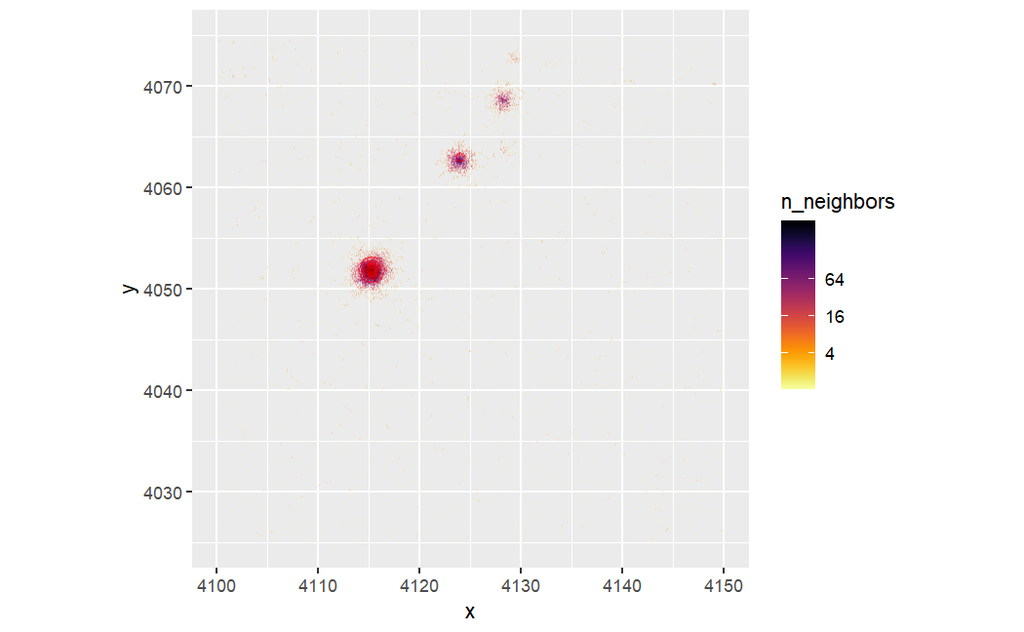

```r
MMcontourData <- ggplot_build(contours)$data[[1]] #extracting the contours (from the optimised function)
MMcombined <- interestAreaModel + geom_path(data = MMcontourData, aes(x = x, y = y, group = group), color = "red", alpha = 0.5)
MMcombined
```

Without the gradient function

```r
initialParams <- c(lambda1 = 0.7, x1 = 4115.261, y1 = 4051.904, alpha1 = 0.683, beta1 = 1.9, x2 = 4124, y2 = 4063, alpha2 = 0.5, beta2 = 1.9)
#the initial parameters for the first component density are the optimal parameters when testing the 2D Moffat Model on an individual source.

lowerbounds = c(0, 3000, 3000, 1e-6, 1+1e-6, 3000, 3000, 1e-6, 1+1e-6)
upperbounds = c(1, 5000, 5000, Inf, Inf, 5000, 5000, Inf, Inf)

MMresult <- optim(par = initialParams, fn = NLLMM2MOFFAT, x = interestArea$x, y = interestArea$y, method = "L-BFGS-B", lower = lowerbounds, upper = upperbounds)

MMresult
```

```
$par
     lambda1           x1           y1       alpha1        beta1           x2
   0.6684551 4115.2411921 4051.8781499    0.4258664    1.3475115 4124.0743175
          y2       alpha2        beta2
4062.9084333    0.9739325    1.2767072

$value
[1] 47833.71

$counts
function gradient
      36       36

$convergence
[1] 0

$message
[1] "CONVERGENCE: REL_REDUCTION_OF_F <= FACTR*EPSMCH"
```

```r
outnogr <- MMresult$par
```

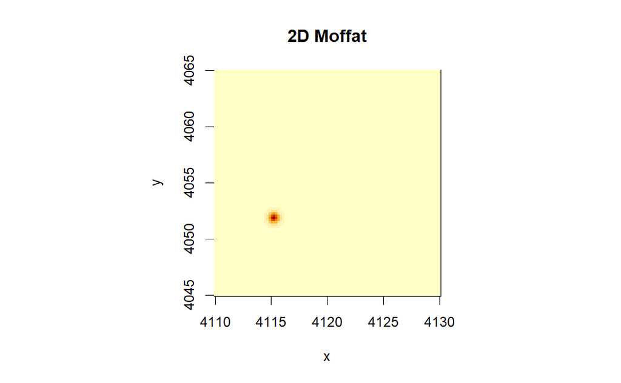

```r
xRange <- seq(4110, 4130, length = 100)
yRange <- seq(4045, 4065, length = 100)
grid <- expand.grid(x = xRange, y = yRange)

oparams <- c(out[[1]], out[[2]], out[[3]], out[[4]], out[[5]], 1-out[[1]], out[[6]], out[[7]], out[[8]], out[[9]])
zMM <- MM2MOFFATimage(grid, params = oparams)
zmat <- matrix(zMM, nrow = length(xRange), ncol = length(yRange))
par(pty = "s")
image(xRange, yRange, zmat, xlab = "x", ylab = "y", main = "2D Moffat")
```

[figure not shown]

```r
contours <- ggplot(grid, aes(x = x, y = y)) +
  stat_contour(aes(z = zMM), bins = 10) +
  coord_fixed()

interestAreaModel <- ggplot(interestArea, aes(x = x, y = y)) +
  geom_pointdensity(adjust = 0.05, size = 0.1, shape = "1") +
  scale_color_viridis(direction = -1, option = "B", trans = "log", breaks = c(4, 16, 64)) +
  coord_fixed()

interestAreaModel
```

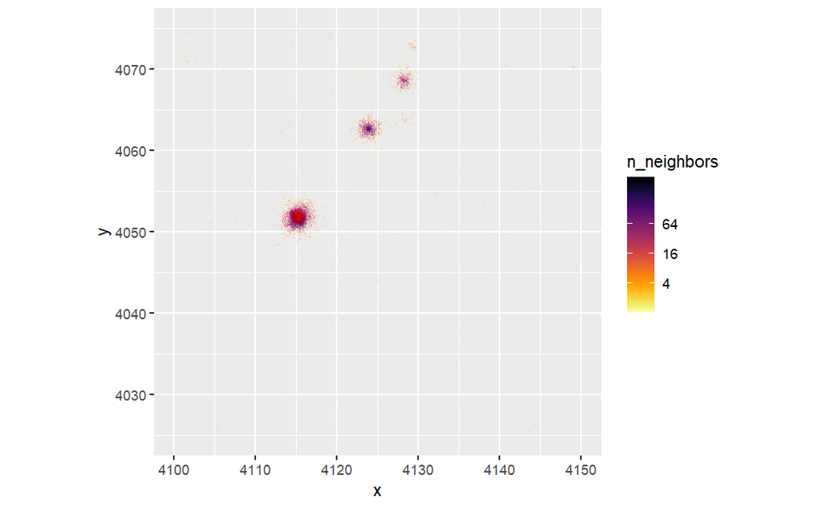

```r
MMcontourData <- ggplot_build(contours)$data[[1]] #extracting the contours (from the optimised function)
MMcombined <- interestAreaModel + geom_path(data = MMcontourData, aes(x = x, y = y, group = group), color = "red", alpha = 0.5)
MMcombined
```

```r
initialParams <- c(lambda1 = 0.7, x1 = 4115.261, y1 = 4051.904, alpha1 = 0.683, beta1 = 1.9, x2 = 4124, y2 = 4063, alpha2 = 0.5, beta2 = 1.9)
#the initial parameters for the first component density are the optimal parameters when testing the 2D Moffat Model on an individual source.

lowerbounds = c(0, 3000, 3000, 1e-6, 1+1e-6, 3000, 3000, 1e-6, 1+1e-6)
upperbounds = c(1, 5000, 5000, Inf, Inf, 5000, 5000, Inf, Inf)

MMresult <- optim(par = initialParams, fn = NLLMM2MOFFAT, gr = derivNLLMM2MOFFAT, x = interestArea$x, y = interestArea$y, method = "L-BFGS-B", lower = lowerbounds, upper = upperbounds, control = list(trace = 6))
```

[output not shown]

[output cut: 134 more lines]

[output not shown]

```
Error in optim(par = initialParams, fn = NLLMM2MOFFAT, gr = derivNLLMM2MOFFAT,  :
  L-BFGS-B needs finite values of 'fn'
```

```r
xRange <- seq(4110, 4130, length = 100)
yRange <- seq(4045, 4065, length = 100)
grid <- expand.grid(x = xRange, y = yRange)

oparams <- c(out[[1]], out[[2]], out[[3]], out[[4]], out[[5]], 1-out[[1]], out[[6]], out[[7]], out[[8]], out[[9]])
zMM <- MM2MOFFATimage(grid, params = oparams)
zmat <- matrix(zMM, nrow = length(xRange), ncol = length(yRange))
par(pty = "s")
image(xRange, yRange, zmat, xlab = "x", ylab = "y", main = "2D Moffat")

contours <- ggplot(grid, aes(x = x, y = y)) +
  stat_contour(aes(z = zMM), bins = 10) +
  coord_fixed()

interestAreaModel <- ggplot(interestArea, aes(x = x, y = y)) +
  geom_pointdensity(adjust = 0.05, size = 0.1, shape = "1") +
  scale_color_viridis(direction = -1, option = "B", trans = "log", breaks = c(4, 16, 64)) +
  coord_fixed()

interestAreaModel

MMcontourData <- ggplot_build(contours)$data[[1]] #extracting the contours (from the optimised function)
MMcombined <- interestAreaModel + geom_path(data = MMcontourData, aes(x = x, y = y, group = group), color = "red", alpha = 0.5)
MMcombined
```

[output not shown]